# Rats Data Set Example

Alexandra Chronopoulou

Lectures 9 Example

## Rat Data from Weisburg (1980)

An experiment is conducted to investigate the amount of a particular drug present in the liver of a rat: 19 rats are randomly selected, weighted, and given an oral dose of the drug, which is approximately proportional to the body weight, (Weisburg, 1980).

- X1: Body weight (g)
- X2: Liver weight (g)
- X3: Relative dose
- Y: Percentage of the dose in the liver

```r
rat=read.table("rat.txt");
dim(rat)
```

```
## [1] 19  4
```

```r
head(rat)
```

```
##    V1  V2   V3   V4
## 1 176 6.5 0.88 0.42
## 2 176 9.5 0.88 0.25
## 3 190 9.0 1.00 0.56
## 4 176 8.9 0.88 0.23
## 5 200 7.2 1.00 0.23
## 6 167 8.9 0.83 0.32
```

Let’s change the names of the data.frame columns, so that it is easier to work with them.

```r
names(rat)=c("body", "liver", "dose", "Y")
```

We first investigate whether the variables with each other are correlated.

```r
cor(rat)
```

```
##            body     liver      dose         Y
## body  1.0000000 0.5000101 0.9902126 0.1510855
## liver 0.5000101 1.0000000 0.4900711 0.2033302
## dose  0.9902126 0.4900711 1.0000000 0.2275436
## Y     0.1510855 0.2033302 0.2275436 1.0000000
```

Among the predictors, we observe that `dose` is highly correlated with `body` by the design of the experiment; `body` and `liver` are known to be correlated from the relevant literature. Observe that the correlations between the predictors and `Y` are low.

Let’s now plot all pairs of variables:

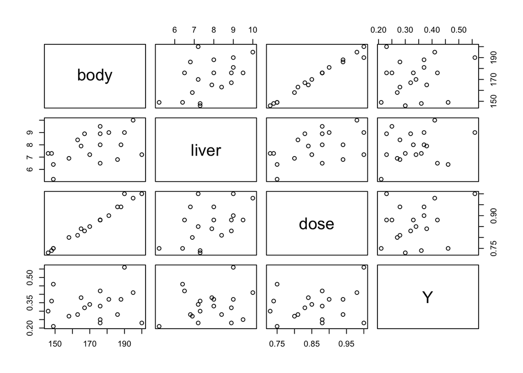

```r
pairs(rat)
```

**How many sub-models we can fit on this data?** Seven, or Eight (if including the intercept-only model).

#### Models with one predictor: Y ~ body, Y ~ liver, Y ~ dose.

```r
summary(lm(Y~body, data=rat))$coef
```

```
##                 Estimate  Std. Error   t value  Pr(>|t|)
## (Intercept) 0.1962346237 0.221582485 0.8856053 0.3881858
## body        0.0008105376 0.001286209 0.6301757 0.5369590
```

```r
summary(lm(Y~liver, data=rat))$coef
```

```
##               Estimate Std. Error   t value  Pr(>|t|)
## (Intercept) 0.22037463 0.13572725 1.6236579 0.1228446
## liver       0.01470945 0.01717914 0.8562387 0.4037739
```

```r
summary(lm(Y~dose, data=rat))$coef
```

```
##              Estimate Std. Error   t value  Pr(>|t|)
## (Intercept) 0.1330050  0.2109117 0.6306194 0.5366756
## dose        0.2346096  0.2435074 0.9634599 0.3488226
```

#### Models with two predictors: Y ~ body + liver, Y ~ body + dose, Y ~ liver + dose.

```r
summary(lm(Y~body+liver, data=rat))$coef
```

```
##                Estimate  Std. Error   t value  Pr(>|t|)
## (Intercept) 0.178356944 0.227775476 0.7830384 0.4450409
## body        0.000353495 0.001513754 0.2335221 0.8183175
## liver       0.012325997 0.020412653 0.6038410 0.5544149
```

```r
summary(lm(Y~body+dose, data=rat))$coef
```

```
##                Estimate Std. Error   t value   Pr(>|t|)
## (Intercept)  0.28551741 0.19126688  1.492770 0.15495313
## body        -0.02044423 0.00783845 -2.608198 0.01902132
## dose         4.12532992 1.50647192  2.738405 0.01457729
```

```r
summary(lm(Y~liver+dose, data=rat))$coef
```

```
##                Estimate Std. Error   t value  Pr(>|t|)
## (Intercept) 0.117365750 0.21909377 0.5356873 0.5995428
## liver       0.008741867 0.02008518 0.4352397 0.6692025
## dose        0.173550533 0.28626117 0.6062664 0.5528430
```

#### Model with all three predictors: Y ~ body + liver + dose.

```r
summary(lm(Y~., data=rat))$coef
```

```
##                Estimate  Std. Error    t value   Pr(>|t|)
## (Intercept)  0.26592177 0.194585255  1.3666080 0.19188433
## body        -0.02124634 0.007974304 -2.6643501 0.01767688
## liver        0.01429806 0.017217141  0.8304549 0.41930376
## dose         4.17811141 1.522625206  2.7440183 0.01506639
```

Tried all seven models. It’s surprising to see that whenever `body` and `dose` are both included in the model, they become significant, otherwise, no variable is significant.

#### Diagnostics

```r
fit=lm(Y~., data=rat);
summary(fit)
```

```
##
## Call:
## lm(formula = Y ~ ., data = rat)
##
## Residuals:
##       Min        1Q    Median        3Q       Max
## -0.100557 -0.063233  0.007131  0.045971  0.134691
##
## Coefficients:
##              Estimate Std. Error t value Pr(>|t|)
## (Intercept)  0.265922   0.194585   1.367   0.1919
## body        -0.021246   0.007974  -2.664   0.0177 *
## liver        0.014298   0.017217   0.830   0.4193
## dose         4.178111   1.522625   2.744   0.0151 *
## ---
## Signif. codes:  0 '***' 0.001 '**' 0.01 '*' 0.05 '.' 0.1 ' ' 1
##
## Residual standard error: 0.07729 on 15 degrees of freedom
## Multiple R-squared:  0.3639, Adjusted R-squared:  0.2367
## F-statistic:  2.86 on 3 and 15 DF,  p-value: 0.07197
```

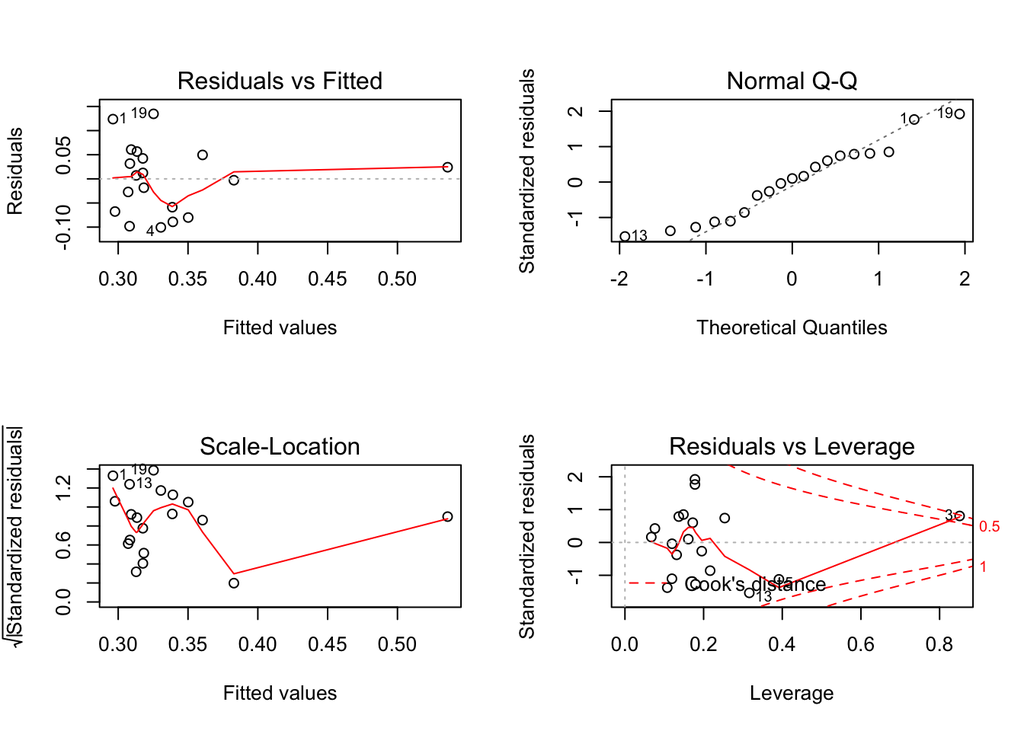

```r
par(mfrow=c(2,2));
plot(fit)
```

A summary of all the diagnostic plots.

#### Check for high-leverage points

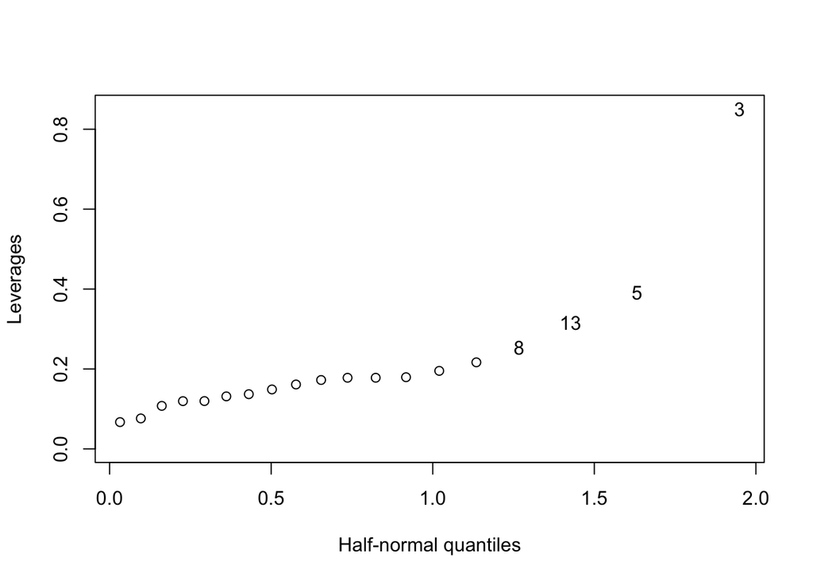

```r
library(faraway)
lev=influence(fit)$hat
halfnorm(lev, 4, ylab="Leverages")
```

```r
n=dim(rats)[1]; # sample size
p=4

# Determine which leverages exceed the 2p/n threshold
newlev = lev[lev>2*p/n]
newlev
```

[output not shown]

#### Check for outliers

```r
sr.ex=rstudent(fit);
sort(sr.ex, decreasing=TRUE)[1:5]
```

```
##        19         1        18         3         7
## 2.1388332 1.9170719 0.8426711 0.7972915 0.7774937
```

```r
qt(0.05/(19*2), 14)
```

```
## [1] -3.64871
```

None o the studentized residuals is higher (in absolute value) than the $t$ distribution threshold, so we conclude that there are no outliers.

#### Check for high-influential points

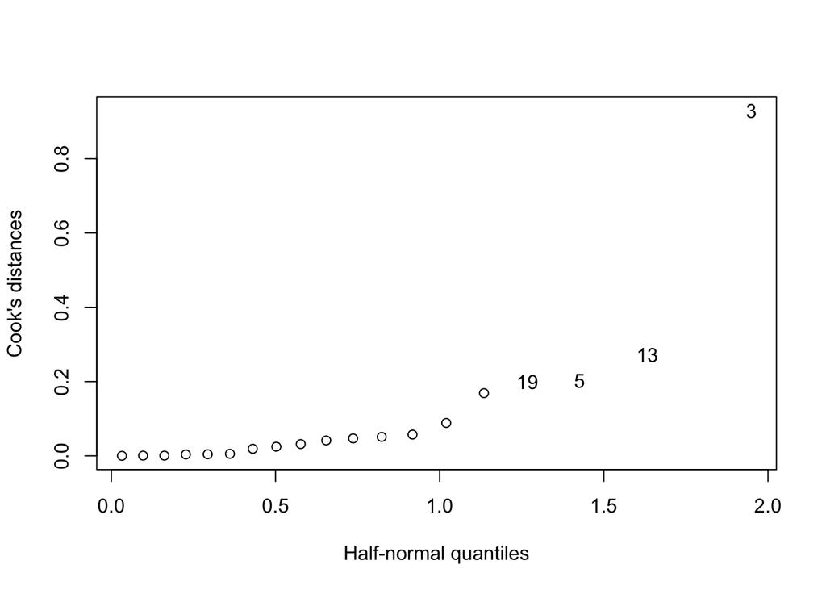

```r
cook = cooks.distance(fit)
halfnorm(cook, 4, ylab="Cook's distances")
```

```r
max(cook)
```

```
## [1] 0.929616
```

```r
which.max(cook)
```

```
## 3
## 3
```

The threshold for Cook’s distance is 1 and this is on the boundary. So,observation `3` might be considered an influential point.

As we can see, the 3rd sample keeps being flagged as an unusual observation. Let’s take a look of the data.

```r
rat
```

```
##    body liver dose    Y
## 1   176   6.5 0.88 0.42
## 2   176   9.5 0.88 0.25
## 3   190   9.0 1.00 0.56
## 4   176   8.9 0.88 0.23
## 5   200   7.2 1.00 0.23
## 6   167   8.9 0.83 0.32
## 7   188   8.0 0.94 0.37
## 8   195  10.0 0.98 0.41
## 9   176   8.0 0.88 0.33
## 10  165   7.9 0.84 0.38
## 11  158   6.9 0.80 0.27
## 12  148   7.3 0.74 0.36
## 13  149   5.2 0.75 0.21
## 14  163   8.4 0.81 0.28
## 15  170   7.2 0.85 0.34
## 16  186   6.8 0.94 0.28
## 17  146   7.3 0.73 0.30
## 18  181   9.0 0.90 0.37
## 19  149   6.4 0.75 0.46
```

Remove the 3rd sample, and refit the model.

```r
newfit=lm(Y~., data=rat, subset=(1:19)[-3])
summary(newfit)
```

```
##
## Call:
## lm(formula = Y ~ ., data = rat, subset = (1:19)[-3])
##
## Residuals:
##       Min        1Q    Median        3Q       Max
## -0.102154 -0.056486  0.002838  0.046519  0.137059
##
## Coefficients:
##              Estimate Std. Error t value Pr(>|t|)
## (Intercept)  0.311427   0.205094   1.518    0.151
## body        -0.007783   0.018717  -0.416    0.684
## liver        0.008989   0.018659   0.482    0.637
## dose         1.484877   3.713064   0.400    0.695
##
## Residual standard error: 0.07825 on 14 degrees of freedom
## Multiple R-squared:  0.02106,    Adjusted R-squared:  -0.1887
## F-statistic: 0.1004 on 3 and 14 DF,  p-value: 0.9585
```

```r
summary(lm(Y~., data=rat))
```

```
##
## Call:
## lm(formula = Y ~ ., data = rat)
##
## Residuals:
##       Min        1Q    Median        3Q       Max
## -0.100557 -0.063233  0.007131  0.045971  0.134691
##
## Coefficients:
##              Estimate Std. Error t value Pr(>|t|)
## (Intercept)  0.265922   0.194585   1.367   0.1919
## body        -0.021246   0.007974  -2.664   0.0177 *
## liver        0.014298   0.017217   0.830   0.4193
## dose         4.178111   1.522625   2.744   0.0151 *
## ---
## Signif. codes:  0 '***' 0.001 '**' 0.01 '*' 0.05 '.' 0.1 ' ' 1
##
## Residual standard error: 0.07729 on 15 degrees of freedom
## Multiple R-squared:  0.3639, Adjusted R-squared:  0.2367
## F-statistic:  2.86 on 3 and 15 DF,  p-value: 0.07197
```

If we compare the models with and without the 3rd observation, we see a difference in the statistical significance of the model parameters. This happens because we identified observation `3` as an influential point, which means that it affects the structure of the fitted model.